# Drink Forecasting Project Summary

Author

Kristie Hermosillo

## 📦 Setup

```r
# install.packages(c("forecast", "ggplot2", "readr", "lubridate", "dplyr")) # Uncomment if not yet installed

library(readr)
library(forecast)
library(ggplot2)
library(lubridate)
library(dplyr)
```

## 📊 Step 1: Load & Prepare Data

```r
psl <- read_csv("psl_weekly.csv")
psl$Week <- as.Date(psl$Week)
ts_psl <- ts(psl$Search_Volume, start = c(2022, 1), frequency = 52)

strawberry <- read_csv("strawberry_matcha_weekly.csv")
strawberry$Week <- as.Date(strawberry$Week)
ts_strawberry <- ts(strawberry$Search_Volume, start = c(2022, 1), frequency = 52)

peppermint <- read_csv("peppermint_mocha_weekly.csv")
peppermint$Week <- as.Date(peppermint$Week)
ts_peppermint <- ts(peppermint$Search_Volume, start = c(2022, 1), frequency = 52)
```

## 🔍 Step 2: Model Each Drink with SARIMA

### PSL

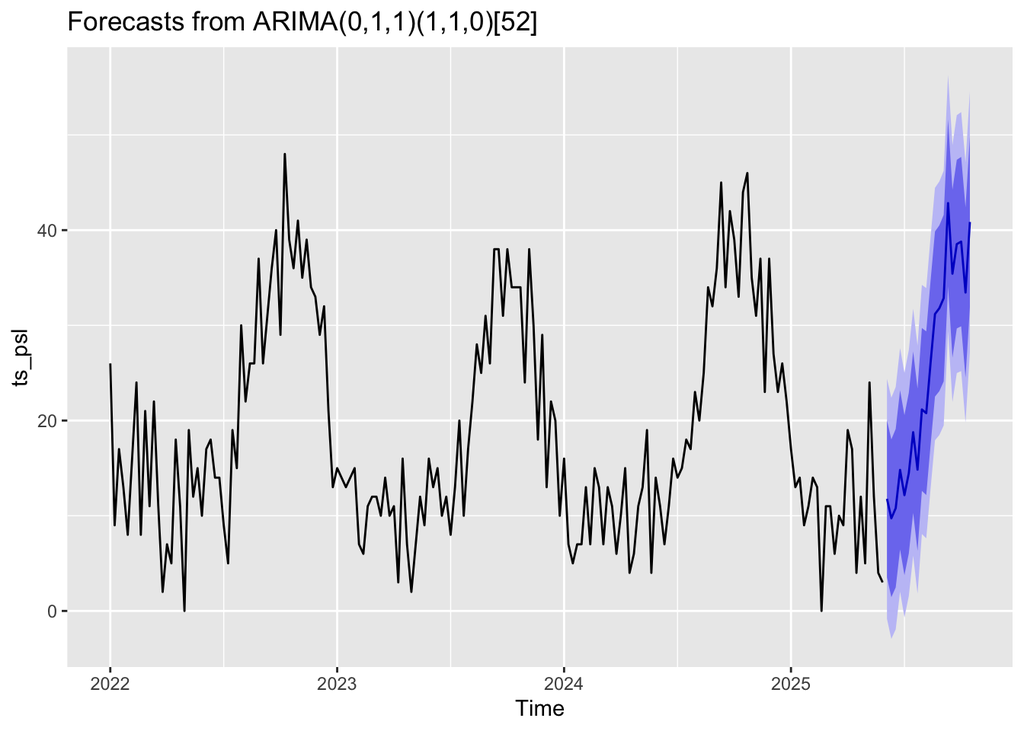

```r
fit_psl <- auto.arima(ts_psl, seasonal = TRUE)
fcast_psl <- forecast(fit_psl, h = 20)
autoplot(fcast_psl)
```

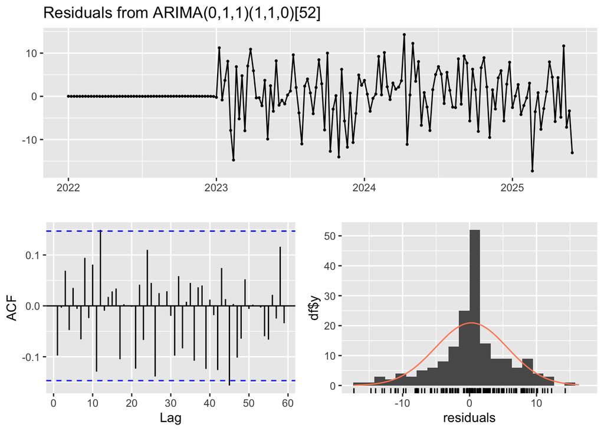

```
    Ljung-Box test

data:  Residuals from ARIMA(0,1,1)(1,1,0)[52]
Q* = 36.522, df = 34, p-value = 0.3523

Model df: 2.   Total lags used: 36
```

```r
checkresiduals(fit_psl)
```

### Strawberry Matcha

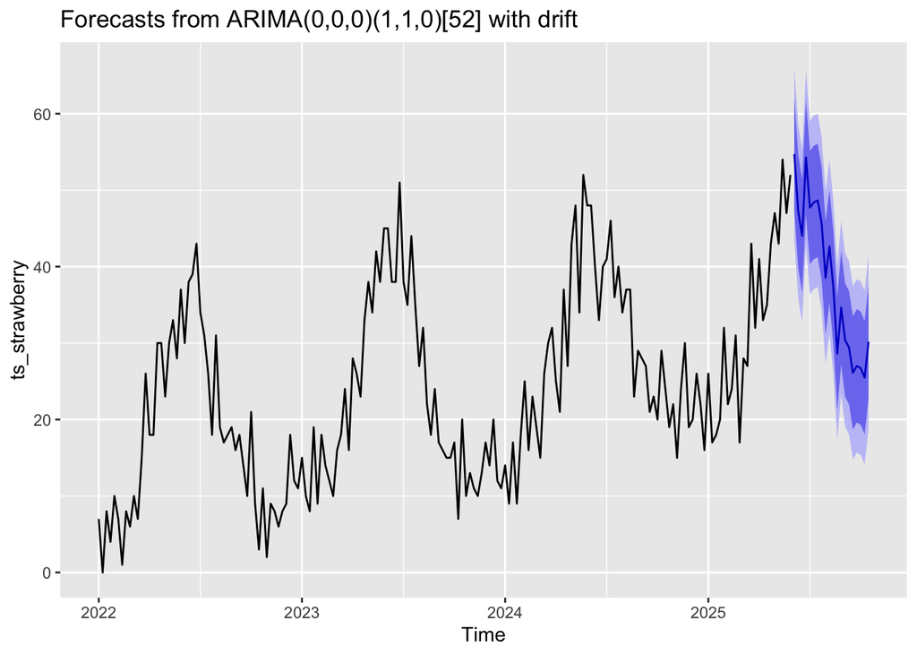

```r
fit_straw <- auto.arima(ts_strawberry, seasonal = TRUE)
fcast_straw <- forecast(fit_straw, h = 20)
autoplot(fcast_straw)
```

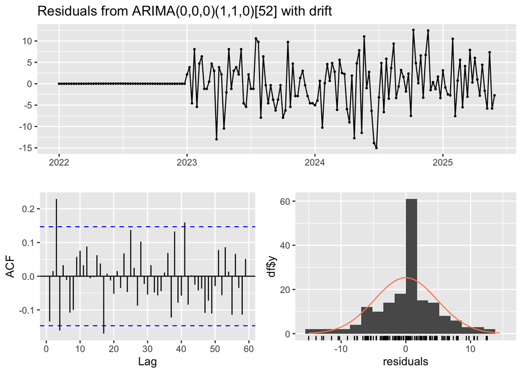

```
    Ljung-Box test

data:  Residuals from ARIMA(0,0,0)(1,1,0)[52] with drift
Q* = 46.221, df = 35, p-value = 0.09719

Model df: 1.   Total lags used: 36
```

```r
checkresiduals(fit_straw)
```

### Peppermint Mocha

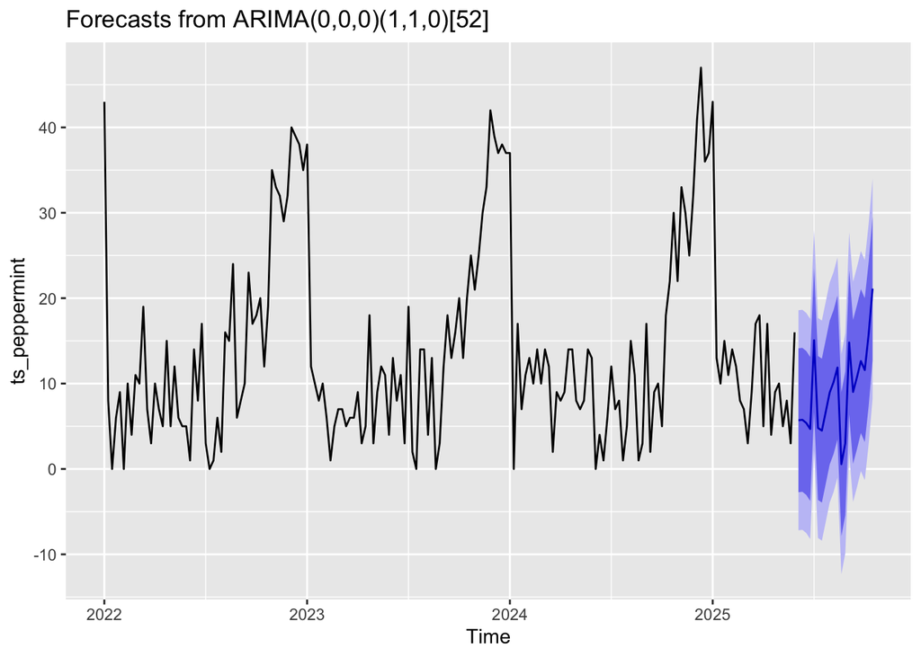

```r
fit_peppermint <- auto.arima(ts_peppermint, seasonal = TRUE)
fcast_peppermint <- forecast(fit_peppermint, h = 20)
autoplot(fcast_peppermint)
```

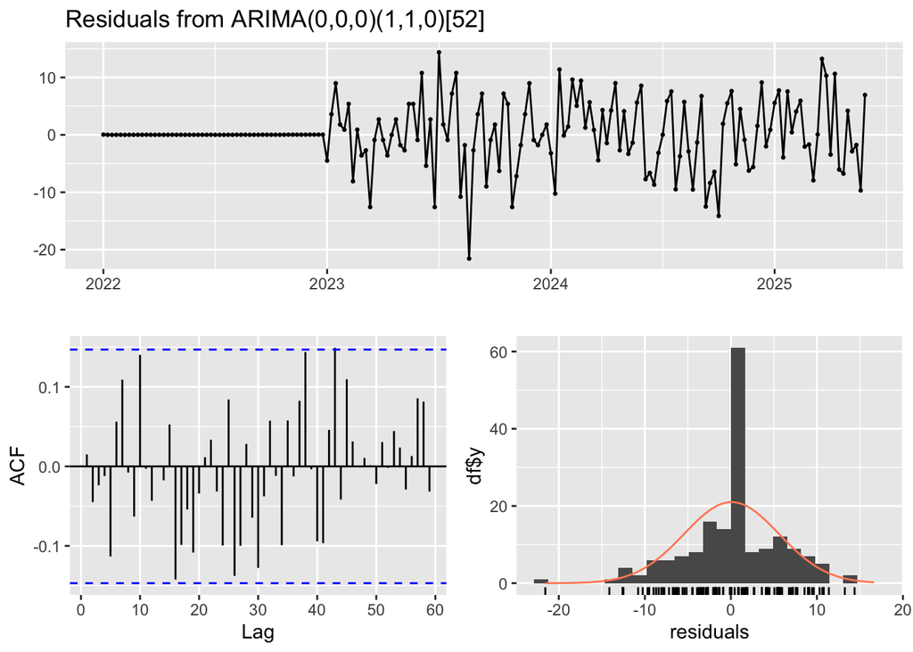

```
    Ljung-Box test

data:  Residuals from ARIMA(0,0,0)(1,1,0)[52]
Q* = 39.108, df = 35, p-value = 0.2905

Model df: 1.   Total lags used: 36
```

```r
checkresiduals(fit_peppermint)
```

## 📈 Model Interpretation Summary

### PSL (Pumpkin Spice Latte)

- **Purpose:** Seasonal benchmark for fall drinks
- **Model:** ARIMA(0,1,1)(1,1,0)[52]
- **Insights:** Strong seasonality with predictable spikes in September–October. Residuals are clean (p = 0.35), meaning model fit is solid.

### Strawberry Matcha

- **Purpose:** Year-round trend assessment
- **Model:** ARIMA(0,0,0)(1,1,0)[52] with drift
- **Insights:** Upward trend emerging. Slightly noisier residuals (p = 0.097), but drift suggests rising popularity.

### Peppermint Mocha

- **Purpose:** Winter holiday demand tracking
- **Model:** ARIMA(0,0,0)(1,1,0)[52]
- **Insights:** Peaks predictably in Nov–Dec. Very clean residuals (p = 0.29), indicating model fits well.

### PSL with Exogenous Variables

- **Purpose:** Test external influence (holiday & temp)
- **Model:** ARIMA(2,0,2)(1,0,0)[52] with regressors
- **Insights:** Holidays have a modest negative coefficient (-2.18), temperature also slightly negative. Suggests PSL spikes aren’t only due to weather or holidays—marketing may matter more.

## 🧪 Step 3: Backtesting Example (PSL)

```r
train_psl <- window(ts_psl, end = c(2024, 52))
test_psl <- window(ts_psl, start = c(2025, 1))

fit_train_psl <- auto.arima(train_psl, seasonal = TRUE)
fcast_test_psl <- forecast(fit_train_psl, h = length(test_psl))
accuracy(fcast_test_psl, test_psl)
```

```
                     ME     RMSE      MAE  MPE MAPE      MASE       ACF1
Training set  0.5296928 5.160061 3.387127 -Inf  Inf 0.5880821 -0.1108597
Test set     -3.6635441 7.172478 5.560468 -Inf  Inf 0.9654235 -0.1281289
             Theil's U
Training set        NA
Test set             0
```

## 🧩 Step 4: Holiday Variable (Optional)

```r
# Make sure this is included to access US holiday functions
library(timeDate)
library(lubridate)

# Create a dataframe of U.S. holidays for 2022–2025
holidays <- data.frame(
  Date = as.Date(c(
    USNewYearsDay(2022:2025),
    USIndependenceDay(2022:2025),
    USThanksgivingDay(2022:2025),
    USChristmasDay(2022:2025)
  ))
)

# Create a Week column rounded to Sunday
holidays$Week <- floor_date(holidays$Date, "week")

# One-hot encode holiday presence
holiday_df <- holidays %>%
  mutate(Holiday_Indicator = 1) %>%
  distinct(Week, .keep_all = TRUE)
```

## 🎉 Step 5: Add Exogenous Variables (Holiday & Temperature)

```r
# Create mock U.S. holiday dates from 2022 to 2025
library(timeDate)

holidays <- data.frame(
  Date = as.Date(c(
    timeDate::USNewYearsDay(2022:2025),
    timeDate::USIndependenceDay(2022:2025),
    timeDate::USThanksgivingDay(2022:2025),
    timeDate::USChristmasDay(2022:2025)
  ))
)

# Convert to weeks
holidays$Week <- floor_date(holidays$Date, "week")

holiday_df <- holidays %>%
  mutate(Holiday_Indicator = 1) %>%
  distinct(Week, .keep_all = TRUE)
```

```r
# Create mock temperature by week from 2022 to 2025
all_weeks <- data.frame(
  Week = seq(as.Date("2022-01-02"), as.Date("2025-06-01"), by = "week")
)

# Add a sinusoidal seasonal pattern
all_weeks$Avg_Temp <- 50 + 20 * sin(2 * pi * as.numeric(format(all_weeks$Week, "%j")) / 365) +
  rnorm(nrow(all_weeks), mean = 0, sd = 5)
```

```r
# Merge in holiday and temperature
psl <- left_join(psl, holiday_df, by = "Week")
psl$Holiday_Indicator[is.na(psl$Holiday_Indicator)] <- 0

psl <- left_join(psl, all_weeks, by = "Week")
```

```r
# Re-fit SARIMA model with external regressors
xreg_matrix <- as.matrix(psl[, c("Holiday_Indicator", "Avg_Temp")])
fit_psl_exog <- auto.arima(
  ts_psl,
  xreg = xreg_matrix,
  stepwise = TRUE,
  approximation = TRUE
)
summary(fit_psl_exog)
```

```
Series: ts_psl
Regression with ARIMA(2,0,2)(1,0,0)[52] errors

Coefficients:
         ar1      ar2      ma1     ma2    sar1  intercept  Holiday_Indicator
      1.8752  -0.9003  -1.6337  0.7406  0.2653    20.9359            -2.1762
s.e.  0.0571   0.0539   0.0737  0.0705  0.1035     5.0963             1.8952
      Avg_Temp
       -0.0399
s.e.    0.0877

sigma^2 = 34.35:  log likelihood = -566.05
AIC=1150.1   AICc=1151.18   BIC=1178.74

Training set error measures:
                      ME     RMSE      MAE  MPE MAPE      MASE        ACF1
Training set -0.06756267 5.727855 4.675683 -Inf  Inf 0.8274383 -0.05210024
```

##Step 6 ## 🔁 Merge Launch Dates

```r
launch_dates <- read_csv("launch_weeks.csv")
psl <- left_join(psl, launch_dates, by = "Week")
strawberry <- left_join(strawberry, launch_dates, by = "Week")
peppermint <- left_join(peppermint, launch_dates, by = "Week")
```

```r
xreg_psl <- as.matrix(psl[, c("Holiday_Indicator", "Avg_Temp", "Launch_PSL")])
fit_psl_launch <- auto.arima(ts_psl, xreg = xreg_psl, stepwise = TRUE, approximation = TRUE)
summary(fit_psl_launch)
```

```
Series: ts_psl
Regression with ARIMA(2,0,2)(1,0,0)[52] errors

Coefficients:
         ar1      ar2      ma1     ma2    sar1  intercept  Holiday_Indicator
      1.8781  -0.9028  -1.6326  0.7371  0.2679    20.8923            -2.1839
s.e.  0.0577   0.0541   0.0729  0.0722  0.1041     5.1223             1.8986
      Avg_Temp  Launch_PSL
       -0.0382     -1.3231
s.e.    0.0887      3.3381

sigma^2 = 34.51:  log likelihood = -565.97
AIC=1151.95   AICc=1153.26   BIC=1183.77

Training set error measures:
                      ME     RMSE      MAE  MPE MAPE      MASE        ACF1
Training set -0.07010561 5.724146 4.684806 -Inf  Inf 0.8290528 -0.05044769
```

```r
# Train/test split for Strawberry Matcha
train_straw <- window(ts_strawberry, end = c(2024, 52))
test_straw <- window(ts_strawberry, start = c(2025, 1))

fit_train_straw <- auto.arima(train_straw, seasonal = TRUE)
fcast_test_straw <- forecast(fit_train_straw, h = length(test_straw))

accuracy(fcast_test_straw, test_straw)
```

```
                      ME     RMSE      MAE       MPE     MAPE      MASE
Training set 0.005786818 4.776579 3.154167      -Inf      Inf 0.4463039
Test set     0.867639128 5.107362 4.380404 0.9420886 13.83198 0.6198122
                    ACF1 Theil's U
Training set -0.09382669        NA
Test set     -0.55393352 0.6078676
```

```r
# Train/test split for Peppermint Mocha
train_peppermint <- window(ts_peppermint, end = c(2024, 52))
test_peppermint <- window(ts_peppermint, start = c(2025, 1))

fit_train_peppermint <- auto.arima(train_peppermint, seasonal = TRUE)
fcast_test_peppermint <- forecast(fit_train_peppermint, h = length(test_peppermint))

accuracy(fcast_test_peppermint, test_peppermint)
```

```
                     ME     RMSE      MAE     MPE     MAPE      MASE
Training set -0.1038818 5.363875 3.494089    -Inf      Inf 0.6138265
Test set      1.3564728 6.559903 5.585951 -26.028 70.25009 0.9813157
                    ACF1 Theil's U
Training set  0.02126880        NA
Test set     -0.05921258  0.751709
```

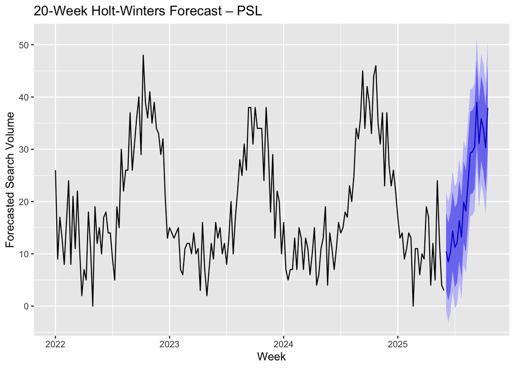

```r
# Holt-Winters for PSL
hw_psl <- HoltWinters(ts_psl)
hw_fcast <- forecast(hw_psl, h = 20)

# Plot forecast
autoplot(hw_fcast) +
  ggtitle("20-Week Holt-Winters Forecast – PSL") +
  xlab("Week") +
  ylab("Forecasted Search Volume")
```

```r
# Compare fit to actual
accuracy(hw_fcast)
```

```
                   ME     RMSE      MAE  MPE MAPE      MASE        ACF1
Training set 0.191598 5.787877 4.258326 -Inf  Inf 0.7535801 -0.07544122
```

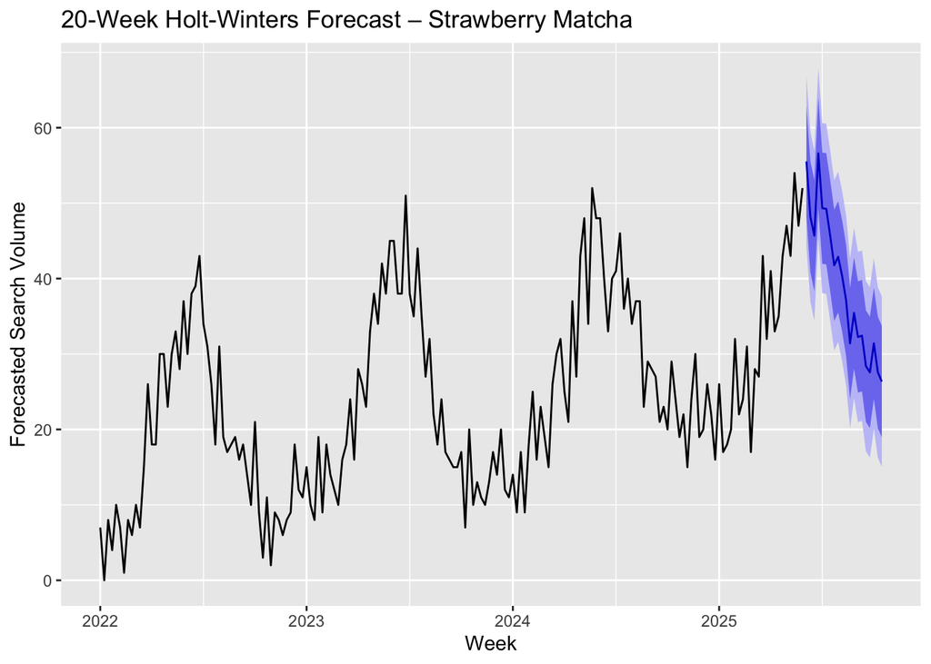

```r
# Holt-Winters for Strawberry Matcha
hw_straw <- HoltWinters(ts_strawberry)
hw_fcast_straw <- forecast(hw_straw, h = 20)

# Plot forecast
autoplot(hw_fcast_straw) +
  ggtitle("20-Week Holt-Winters Forecast – Strawberry Matcha") +
  xlab("Week") +
  ylab("Forecasted Search Volume")
```

```r
# Accuracy
accuracy(hw_fcast_straw)
```

```
                    ME     RMSE     MAE        MPE     MAPE     MASE       ACF1
Training set 0.5987613 5.757693 4.51614 -0.4450781 20.66633 0.623257 -0.1610843
```

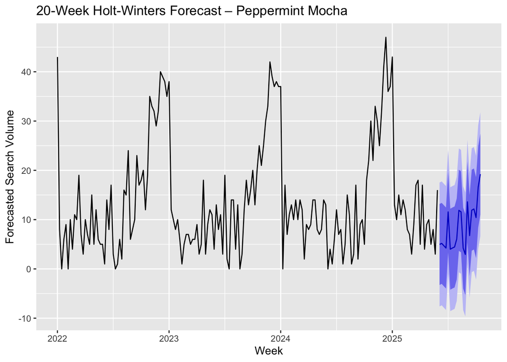

```r
# Holt-Winters for Peppermint Mocha
hw_peppermint <- HoltWinters(ts_peppermint)
hw_fcast_peppermint <- forecast(hw_peppermint, h = 20)

# Plot forecast
autoplot(hw_fcast_peppermint) +
  ggtitle("20-Week Holt-Winters Forecast – Peppermint Mocha") +
  xlab("Week") +
  ylab("Forecasted Search Volume")
```

```r
# Accuracy
accuracy(hw_fcast_peppermint)
```

```
                    ME     RMSE      MAE  MPE MAPE      MASE       ACF1
Training set 0.3923829 6.398131 4.684764 -Inf  Inf 0.8198338 0.06283633
```

## 🔁 Holt-Winters Model Summary

We applied Holt-Winters exponential smoothing to each drink to assess how well a simpler seasonal model compares to our SARIMA results.

### 🎃 Pumpkin Spice Latte (PSL)

- RMSE: 5.79 | MAE: 4.26 | MASE: 0.75
- Residuals well-behaved (ACF1 = -0.075)
- ⚡ Nearly identical performance to SARIMA—strong seasonal pattern

### 🍓 Strawberry Matcha

- RMSE: 5.76 | MAE: 4.52 | MASE: 0.62
- Slightly noisier trend but model still holds
- ✅ Holt-Winters provides reasonable short-term forecasts

### 🍬 Peppermint Mocha

- RMSE: 6.40 | MAE: 4.68 | MASE: 0.82
- Residuals less stable (ACF1 = 0.06)
- ⚠️ SARIMA likely remains the better fit for capturing sharper holiday spikes

### 💡 Conclusion:

Holt-Winters is a solid fallback option and performs especially well with strongly seasonal drinks like PSL. For drinks with trend or volatility (like Strawberry Matcha or Peppermint Mocha), SARIMA offers better control and precision.

## 🚧 To-Do / Remaining Steps

- Format and clean Google Trends data for all drinks
- Build baseline SARIMA models for PSL, Strawberry Matcha, and Peppermint Mocha
- Backtest PSL using train/test split
- Generate forecast visualizations and residual diagnostics
- Add holiday calendar and temperature data to PSL
- Apply exogenous regressors to Strawberry and Peppermint (optional)
- Add drink launch dates (manual or estimated)
- Run Holt-Winters comparison (for at least PSL)
- Finalize executive summary and Canva slides
- Prep speaker notes for 10–12 minute team presentation